# Relationship between MBTI personality types and physical traits

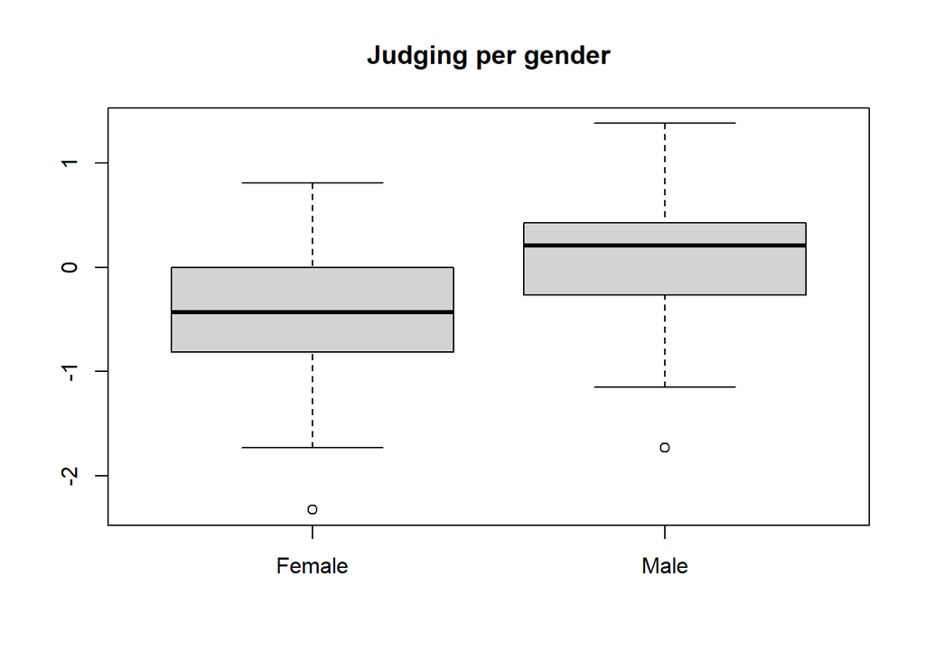

```r
boxplot(dataset_mbti[dataset_mbti$SEX == "Female",]$T,
        dataset_mbti[dataset_mbti$SEX == "Male",]$T,
        names = c("Female", "Male"),
        main = "Judging per gender")
```

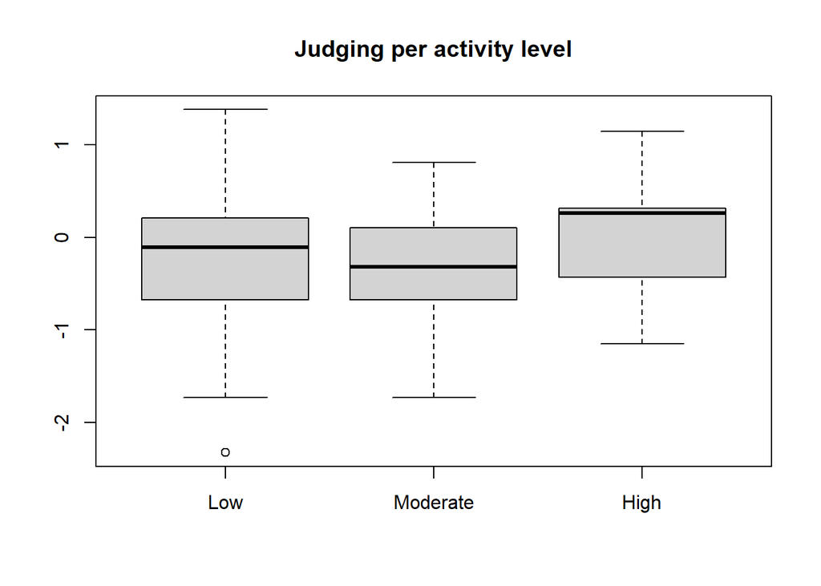

```r
boxplot(dataset_mbti[dataset_mbti$ACTIVITY.LEVEL == "Low",]$T,
        dataset_mbti[dataset_mbti$ACTIVITY.LEVEL == "Moderate",]$T,
        dataset_mbti[dataset_mbti$ACTIVITY.LEVEL == "High",]$T,
        names = c("Low", "Moderate", "High"),
        main = "Judging per activity level")
```

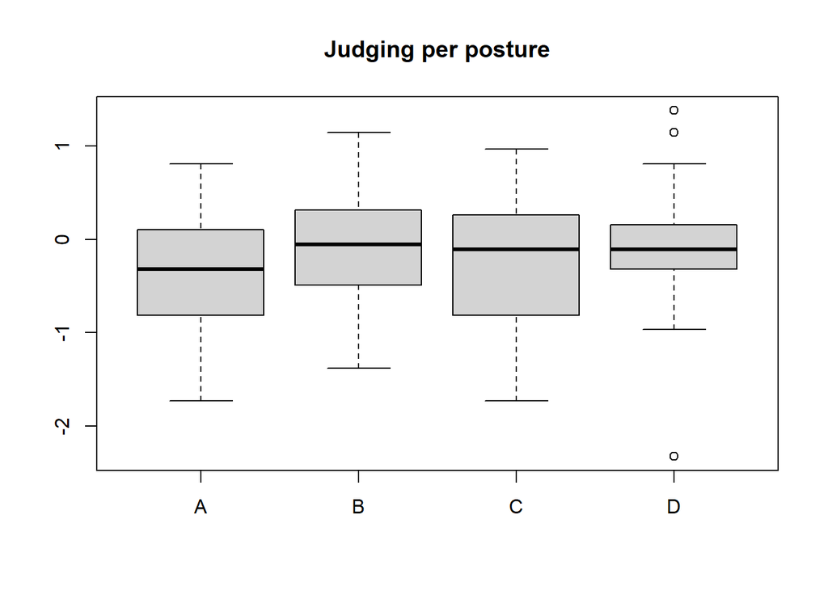

```r
boxplot(dataset_mbti[dataset_mbti$POSTURE == "A",]$T,
        dataset_mbti[dataset_mbti$POSTURE == "B",]$T,
        dataset_mbti[dataset_mbti$POSTURE == "C",]$T,
        dataset_mbti[dataset_mbti$POSTURE == "D",]$T,
        names = c("A", "B", "C", "D"),
        main = "Judging per posture")
```

Use fastDummies for posture and MBTI gruops, beware of co-linear columns

```r
summary(lm(E ~ POSTURE_INT + PAIN.1 + PAIN.4 + HEIGHT_CM + WEIGHT_KG + F, dataset_mbti))
```

```
##
## Call:
## lm(formula = E ~ POSTURE_INT + PAIN.1 + PAIN.4 + HEIGHT_CM +
##     WEIGHT_KG + F, data = dataset_mbti)
##
## Residuals:
##      Min       1Q   Median       3Q      Max
## -1.81297 -0.41801  0.02101  0.44904  1.83507
##
## Coefficients:
##              Estimate Std. Error t value Pr(>|t|)
## (Intercept)  1.941070   1.340775   1.448 0.151169
## POSTURE_INT -0.387763   0.065694  -5.903 6.23e-08 ***
## PAIN.1      -0.095126   0.027608  -3.446 0.000868 ***
## PAIN.4       0.076014   0.024105   3.153 0.002194 **
## HEIGHT_CM   -0.004014   0.009010  -0.445 0.657033
## WEIGHT_KG   -0.001609   0.005311  -0.303 0.762589
## F            0.100323   0.101536   0.988 0.325773
## ---
## Signif. codes:  0 '***' 0.001 '**' 0.01 '*' 0.05 '.' 0.1 ' ' 1
##
## Residual standard error: 0.6535 on 90 degrees of freedom
## Multiple R-squared:  0.3728, Adjusted R-squared:  0.331
## F-statistic: 8.917 on 6 and 90 DF,  p-value: 1.232e-07
```

```r
summary(lm(J ~ POSTURE_INT, dataset_mbti))
```

```
##
## Call:
## lm(formula = J ~ POSTURE_INT, data = dataset_mbti)
##
## Residuals:
##      Min       1Q   Median       3Q      Max
## -1.83802 -0.63601 -0.00267  0.54601  1.61267
##
## Coefficients:
##             Estimate Std. Error t value Pr(>|t|)
## (Intercept) -0.70657    0.18742  -3.770 0.000283 ***
## POSTURE_INT  0.21824    0.07201   3.031 0.003145 **
## ---
## Signif. codes:  0 '***' 0.001 '**' 0.01 '*' 0.05 '.' 0.1 ' ' 1
##
## Residual standard error: 0.7445 on 95 degrees of freedom
## Multiple R-squared:  0.08815,    Adjusted R-squared:  0.07856
## F-statistic: 9.184 on 1 and 95 DF,  p-value: 0.003145
```

```r
summary(lm(POSTURE_INT ~ E + S + T + J, dataset_mbti))
```

```
##
## Call:
## lm(formula = POSTURE_INT ~ E + S + T + J, data = dataset_mbti)
##
## Residuals:
##     Min      1Q  Median      3Q     Max
## -2.3938 -0.5988 -0.1425  0.6208  1.8683
##
## Coefficients:
##              Estimate Std. Error t value Pr(>|t|)
## (Intercept)  2.526978   0.110889  22.788  < 2e-16 ***
## E           -0.602411   0.124474  -4.840 5.22e-06 ***
## S           -0.210492   0.268591  -0.784   0.4352
## T            0.004946   0.141697   0.035   0.9722
## J            0.245100   0.132557   1.849   0.0677 .
## ---
## Signif. codes:  0 '***' 0.001 '**' 0.01 '*' 0.05 '.' 0.1 ' ' 1
##
## Residual standard error: 0.9187 on 92 degrees of freedom
## Multiple R-squared:  0.2736, Adjusted R-squared:  0.242
## F-statistic: 8.661 on 4 and 92 DF,  p-value: 5.602e-06
```

```r
summary(lm(ACTIVITY.LEVEL_INT ~ E + S + T + J, dataset_mbti))
```

```
##
## Call:
## lm(formula = ACTIVITY.LEVEL_INT ~ E + S + T + J, data = dataset_mbti)
##
## Residuals:
##      Min       1Q   Median       3Q      Max
## -0.57237 -0.32440 -0.23422 -0.03644  1.75835
##
## Coefficients:
##             Estimate Std. Error t value Pr(>|t|)
## (Intercept)  1.22487    0.06951  17.622   <2e-16 ***
## E            0.01988    0.07802   0.255   0.7995
## S           -0.31941    0.16836  -1.897   0.0609 .
## T            0.05633    0.08882   0.634   0.5275
## J           -0.06142    0.08309  -0.739   0.4617
## ---
## Signif. codes:  0 '***' 0.001 '**' 0.01 '*' 0.05 '.' 0.1 ' ' 1
##
## Residual standard error: 0.5759 on 92 degrees of freedom
## Multiple R-squared:  0.05635,    Adjusted R-squared:  0.01532
## F-statistic: 1.373 on 4 and 92 DF,  p-value: 0.2493
```

```r
summary(lm(SEX_INT ~ E + S + T + J, dataset_mbti))
```

```
##
## Call:
## lm(formula = SEX_INT ~ E + S + T + J, data = dataset_mbti)
##
## Residuals:
##     Min      1Q  Median      3Q     Max
## -0.7874 -0.3549  0.0407  0.3638  0.7496
##
## Coefficients:
##             Estimate Std. Error t value Pr(>|t|)
## (Intercept)  1.46157    0.05127  28.508  < 2e-16 ***
## E            0.04024    0.05755   0.699  0.48613
## S           -0.31913    0.12418  -2.570  0.01178 *
## T            0.37748    0.06551   5.762  1.1e-07 ***
## J           -0.16960    0.06129  -2.767  0.00683 **
## ---
## Signif. codes:  0 '***' 0.001 '**' 0.01 '*' 0.05 '.' 0.1 ' ' 1
##
## Residual standard error: 0.4248 on 92 degrees of freedom
## Multiple R-squared:  0.3155, Adjusted R-squared:  0.2857
## F-statistic:  10.6 on 4 and 92 DF,  p-value: 4.16e-07
```

# RQ-5: Are women more feeling than men?

*[HR]* Jesu li žene osjećajnije nego muškarci?

## Independency

H0: There is no difference in the distribution of the Feeling variable between men and women.

H1: There is a difference in the distribution of the Feeling variable between men and women.

```r
contingency_table <- table(dataset_mbti$SEX, dataset_mbti$MBTI_TF)
contingency_table
```

```
##
##           F  T
##   Female 39 10
##   Male   20 28
```

```r
chi_sq_test <- chisq.test(contingency_table)
print(chi_sq_test)
```

```
##
##  Pearson's Chi-squared test with Yates' continuity correction
##
## data:  contingency_table
## X-squared = 13.088, df = 1, p-value = 0.0002972
```

We can reject null hypothesis. There is a significant difference in the distribution of the Feeling variable between men and women.

## Test of proportions

H0: The proportion of individuals classified as Feeling is the same for men and women.

H1: The proportion of individuals classified as Feeling is higher for women compared to men.

```r
feeling_counts <- contingency_table["Female", "F"]
total_counts <- rowSums(contingency_table)

proportion_test <- prop.test(feeling_counts, total_counts["Female"])
proportion_test
```

```
##
##  1-sample proportions test with continuity correction
##
## data:  feeling_counts out of total_counts["Female"], null probability 0.5
## X-squared = 16, df = 1, p-value = 6.334e-05
## alternative hypothesis: true p is not equal to 0.5
## 95 percent confidence interval:
##  0.6523763 0.8927585
## sample estimates:
##         p
## 0.7959184
```

p-value = 6.334e-05 < significance level = 0.05 We can reject null hypothesis.

The confidence interval, ranging from 0.6523763 to 0.8927585, gives us a likely range for the true proportion of individuals labeled as “Feeling” in the entire population. The sample estimate p is 0.7959184 and it suggests that in our sample, a substantial proportion of females are classified as “Feeling.” If there was no difference, the expected proportion would be 0.5. In simpler terms, this indicates that in our sample a larger number of females are likely to be classified as “Feeling” rather than not.

## Conclusion

Women are more feeling than men.

# Resources

1. Sylvain Guimond, Wael Massrieh: Intricate Correlation between Body Posture, Personality Trait and Incidence of Body Pain: A Cross-Referential Study Report (https://doi.org/10.1371/journal.pone.0037450)